# LuthraSauravPS5A

Saurav Luthra

2025-04-05

# SAURAV LUTHRA, MTH643 PROBLEM SET 5A

## =========== OVERVIEW ===========

**HP :** Helmerich & Payne, Inc. (NYSE)

**PDS :** Precision Drilling Corporation (NYSE)

## =========== SETUP ===========

```r
# ==============================================================================
# GET PRICE DATA, LOG-RETURNS, ETC.

getSymbols("HP", src = "yahoo", from = as.Date("2020-02-01", to = as.Date("2025-02-01")))
```

```
## [1] "HP"
```

```r
HP_prices <- (HP$HP.Adjusted)
HP_log_returns <- as.vector(diff(log(HP_prices))[-1])

getSymbols("PDS", src = "yahoo", from = as.Date("2020-02-01", to = as.Date("2025-02-01")))
```

```
## [1] "PDS"
```

```r
PDS_prices <- (PDS$PDS.Adjusted)
PDS_log_returns <- as.vector(diff(log(PDS_prices))[-1])

n <- length(HP_log_returns)
cor_tau = cor(HP_log_returns, PDS_log_returns, method="kendall")

# ==============================================================================
# UNIVARIATE T-DISTRIBUTIONS

est_HP = as.numeric(fitdistr(HP_log_returns, "t")$estimate)
std_HP <- est_HP[2] * sqrt(est_HP[3] / (est_HP[3] - 2))

est_PDS = as.numeric(fitdistr(PDS_log_returns, "t")$estimate)
std_PDS <- est_PDS[2] * sqrt(est_PDS[3] / (est_PDS[3] - 2))

# ==============================================================================
# UNIFORM-TRANSFORMED DATA

data1 = cbind(pstd(HP_log_returns, est_HP[1], std_HP, est_HP[3]), pstd(PDS_log_returns, est_PDS[1], std_PDS, est_PDS[3]))
```

## =========== QUESTION 1 ===========

#### [**Empirical Copula of HP & PDS Log Returns**]

Compared to the Clayton Copula, the Empirical Copula’s contour lines suggest a higher cumulative probability towards the middle of the uniform-transformed bivariate distribution. At the 0.1, 0.2, 0.3, and 0.4 contour lines, the red contour lines are inside (higher than) the Clayton Copula’s line. At the 0.9, 0.8, 0.7, and 0.6 contour lines, the red contour lines are also inside (lower than) the Clayton copula’s contour lines. This means that the tail dependence isn’t as high as the Clayton copula might suggest, and that most of these bivariate observations are actually found in a ‘tighter’ region/band in middle area of the 2D distribution. Generally, the contour lines are quite similar and close to each other, so the surfaces have a very similar shape (generated with the ‘persp’ command).

```r
# ==============================================================================
# SETUP

# define a grid of (u,v) values
u_vals = seq(0, 1, length.out = 50)  # 50 points from 0 to 1
v_vals = seq(0, 1, length.out = 50)

# create a meshgrid of all (u,v) pairs
grid = expand.grid(u_vals, v_vals)
colnames(grid) = c("u", "v")

nr = length(u_vals)
nc = length(v_vals)

# ==============================================================================
# FIT THE CLAYTON COPULA, OUTPUT ESTIMATED PARAMETERS & STANDARD ERRORS

fclayton = fitCopula(copula=claytonCopula(1,dim=2),data=data1, method="ml")

cat("\n------------------------------\n")
cat("Clayton Copula:")
```

```
## Clayton Copula:
```

```r
cat("\n------------------------------\n")
cat(sprintf("Parameter: Estimate = %.4f, SE = %.4f\n", coef(fclayton), sqrt(diag(vcov(fclayton)))))
```

```
## Parameter: Estimate = 1.8484, SE = 0.0734
```

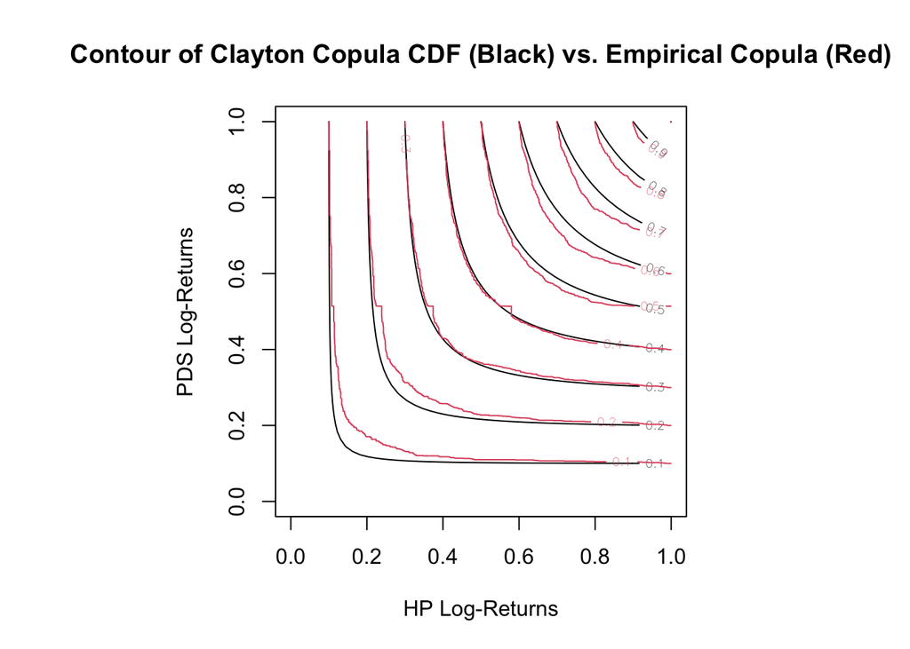

```r
# ==============================================================================
# CLAYTON COPULA CONTOUR CDF DIAGRAM

cdf_vals_clayton = pCopula(as.matrix(grid), copula = fclayton@copula)
cdf_matrix_clayton = matrix(cdf_vals_clayton, nrow = nr, ncol = nc)
par(pty = "s")
contour(u_vals, v_vals, cdf_matrix_clayton, xlab="HP Log-Returns", ylab="PDS Log-Returns", main="Contour of Clayton Copula CDF (Black) vs. Empirical Copula (Red)")

# ==============================================================================
# CREATE AND DISPLAY THE EMPIRICAL COPULA

Udex = (1:n)/(n+1)

eval_pts = cbind(rep(Udex,n), rep(Udex,each=n))

Cn = C.n(u=eval_pts, X=data1) # method="C"

# EmpCop = expression(contour(Udex, Udex, matrix(Cn, n, n), col = 2, add = TRUE))
contour(Udex, Udex, matrix(Cn, n, n), col = 2, add = TRUE)
```

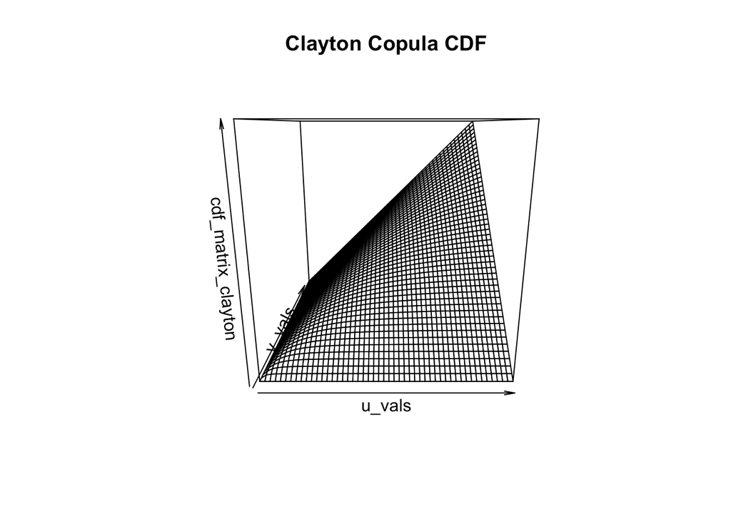

```r
# ==============================================================================
# DISPLAY THE 3D CDF SURFACE OF EACH COPULA

persp(u_vals, v_vals, cdf_matrix_clayton, main="Clayton Copula CDF")
```

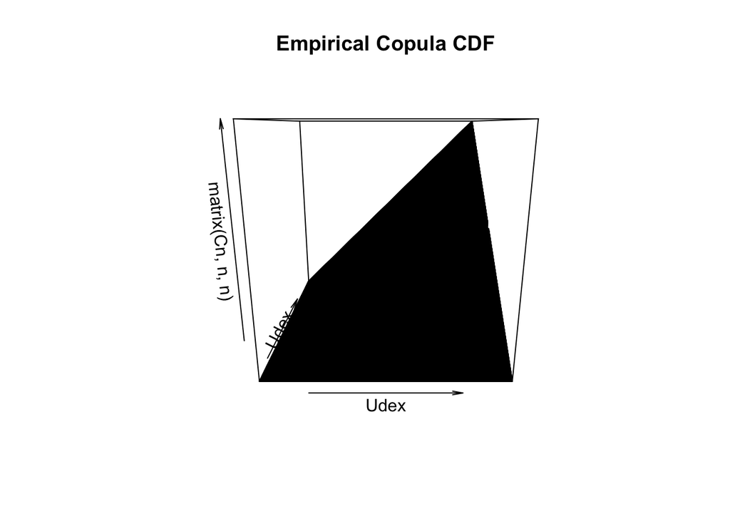

```r
persp(Udex, Udex, matrix(Cn, n, n), main="Empirical Copula CDF")
```

## =========== QUESTION 2 ===========

#### [**Clayton Copula PDF vs Kernel Density Estimate of HP & PDS Log-Returns**]

The Clayton Copula Probability Density Function (PDF) and the Kernel Density Estimate PDF are both plotted and compared, and turned out to have very different characteristics. The Clayton Copula has a much stronger emphasis on the relationships between the tails of the distributions (strong correlations near (1,1) and (0,0)). There’s 2 distinct peaks there indicating that there is a very high probability of HP and PDS jointly (quantile pairs) moving down strongly or up strongly at the same time. The PDF surface is much more “sparse” towards the center. Interestingly, the KDE Copula PDF has 3 “mountain peaks”, all along the V=U line. According to the KDE, the joint probability is strongest near strong moves up (1,1), strong moves down (0,0), and moves that are slightly positive (0.6,0.6). Since the count of moves up/moves down is nearly balanced, we can approximately say that (0.6,0.6) on the uniform-transformed scale probably corresponds to the numerous and common instances where the stocks moderately and consistently drift upwards in price jointly.

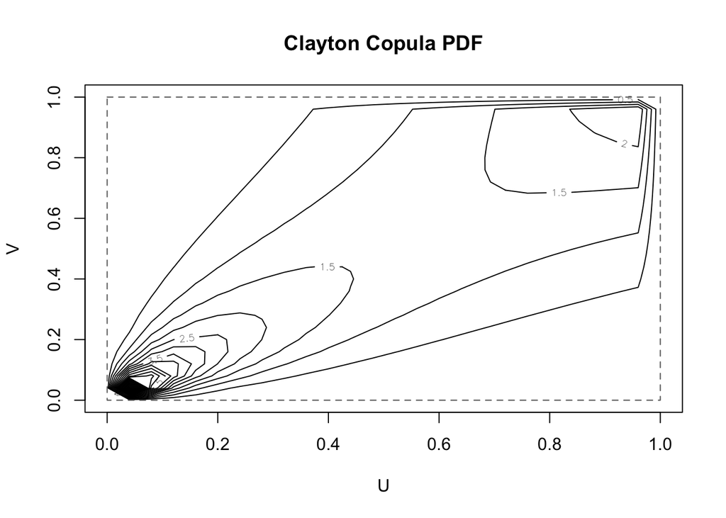

```r
contour(claytonCopula(param=fclayton@estimate[1], dim=2), dCopula, main="Clayton Copula PDF", nlevels=25, xlab="U", ylab="V")
```

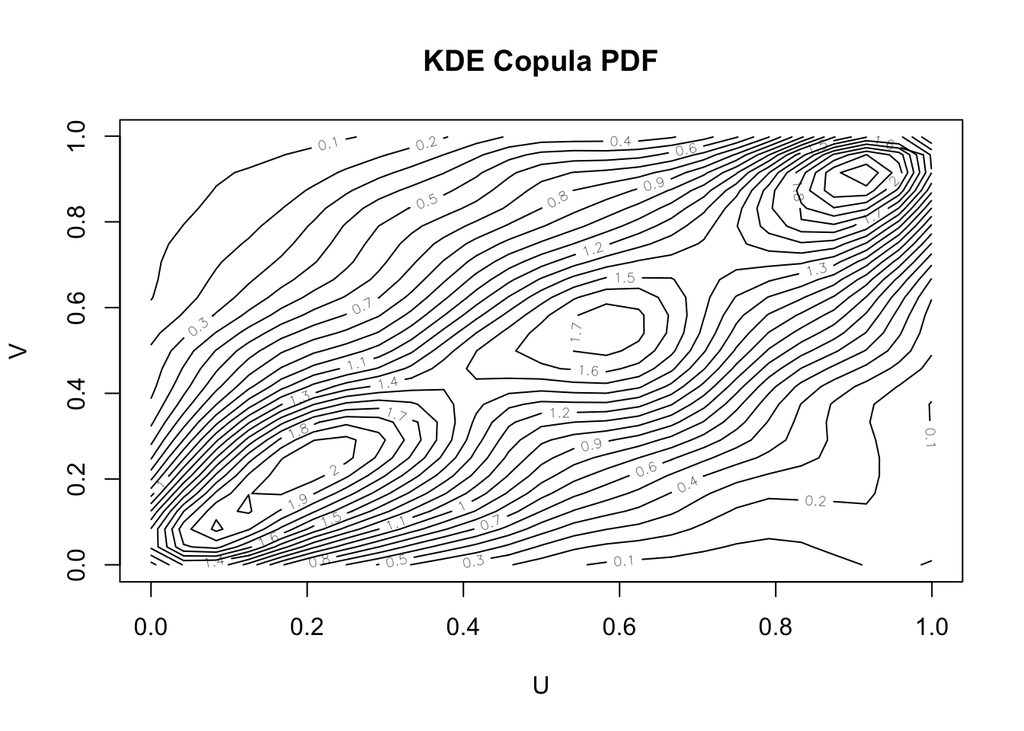

```r
contour(kde2d(data1[,1], data1[,2]), dCopula, main="KDE Copula PDF", nlevels=25, xlab="U", ylab="V")
```

## =========== QUESTION 3 ===========

#### [**Estimating** $\hat{\alpha}$ Using Bootstrapping Technique]

To optimize the risk (when risk is defined as the variance of log-returns) of a joint portfolio of HP (**x**) and PDS (**y**), we aim to estimate a proportion of our protfolio to allocate to **x** (α), and the proportion of the portfolio to allocate to **y** (1 - α). This estimate is $\hat{\alpha}$ (α-hat), and is derived to be given by the following formula:

$$\alpha = \frac{\sigma_y - \sigma_{xy}}{\sigma_x + \sigma_y -
2\sigma_{xy}}$$

Since there is no feasible way to know the true variance (population parameters) of the log-returns of x or y, we need to estimate them using sampling. The sample variances are used instead to compute an estimate for α, according to:

$$\hat{\alpha} = \frac{s_y - s_{xy}}{s_x + s_y - 2s_{xy}}$$

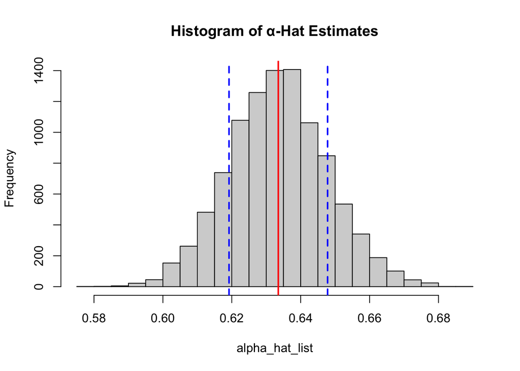

```r
# ==============================================================================
# SETUP

set.seed(305)

sample_size <- 50000
iterations <- 10000

log_returns_matrix <- cbind(HP_log_returns, PDS_log_returns)
alpha_hat_list <- rep(0, iterations)

for (i in 1:iterations){

  # randomly sample row indices with replacement
  sample_indices <- sample(1:nrow(log_returns_matrix), size = sample_size, replace = TRUE)

  # create a new matrix with the selected rows
  sampled_matrix <- log_returns_matrix[sample_indices, ]

  # get the sample stats
  sx  <- var(sampled_matrix[,1])
  sy  <- var(sampled_matrix[,2])
  sxy <- cov(sampled_matrix[,1], sampled_matrix[,2])

  # get estimate for α-hat based on the random sample
  alpha_hat <- (sy - sxy)/(sx + sy - 2*sxy)
  alpha_hat_list[i] <- alpha_hat
}

# histogram of α-hat estimates
hist(alpha_hat_list,breaks = 25, main="Histogram of α-Hat Estimates")

# add vertical lines at mean and +- 1 standard deviation)
abline(v = mean(alpha_hat_list), col = "red", lwd = 2)  # Mean
abline(v = mean(alpha_hat_list) + sd(alpha_hat_list), col = "blue", lwd = 2, lty = 2)
abline(v = mean(alpha_hat_list) - sd(alpha_hat_list), col = "blue", lwd = 2, lty = 2)
```

```r
cat("α-Hat Estimate:\n")
```

```
## α-Hat Estimate:
```

```r
cat(mean(alpha_hat_list))
```

```
## 0.6334991
```

```r
cat("\nVariance of α-Hat Estimate:\n")
```

```
##
## Variance of α-Hat Estimate:
```

```r
cat(var(alpha_hat_list))
```

```
## 0.0002046616
```

```r
cat("\nStd Dev of α-Hat Estimate:\n")
```

```
##
## Std Dev of α-Hat Estimate:
```

```r
cat(sd(alpha_hat_list))
```

```
## 0.014306
```